# Final Project_EDA

Priyasha Chawla

24/04/2022

```r
# load the data
voting_data <- read_csv("CES20_Common_OUTPUT_vv.csv") %>%
  select(CC20_401, birthyr, gender, educ, race, CC20_332a, CC20_302, CC20_309e, CC20_350b, urbancity, ideo5, pew_religimp, ownhome,newsint, faminc_new, investor, internethome, sexuality, CC20_331e, gunown, child18, votereg, presvote16post, CC20_303, CC20_307, employ, marstat, immstat, phone, CC20_300_1,CC20_300_2, CC20_300_3, CC20_300_4, CC20_300_5, CC20_300a, CC20_300c , CC20_320d, CC20_320b, race, inputstate, CC20_430a_1, CC20_430a_2, CC20_430a_3, CC20_430a_4, CC20_430a_5, CC20_430a_6, CC20_430a_7)
```

```
## * `` -> ...1
```

```r
# create age variable, filter registered voters and drop missing values
voting_data <- voting_data %>%
  mutate(birthyr = 2020 - birthyr) %>%
  filter(votereg == 1) %>%
  na.omit()

# recode internet at home to match implemtation data
voting_data <- voting_data %>%
  mutate(internethome = if_else(condition = internethome <= 2, true = 1,
                                false = 2))

# create a binary variable for voted or not and convert to factor
voting_data <- voting_data %>%
    mutate(voted = if_else(condition = CC20_401 == 5, true = 1,
                               false = 0))%>%
  mutate(voted = factor(voted, labels = c("1", "0"), levels = c("1", "0")))

# drop voter registration (since it is a prerequiste, not a predictor)
voting_data <- voting_data %>%
  select(-votereg)
```

###Descriptive statistics ###Sample distribution by race

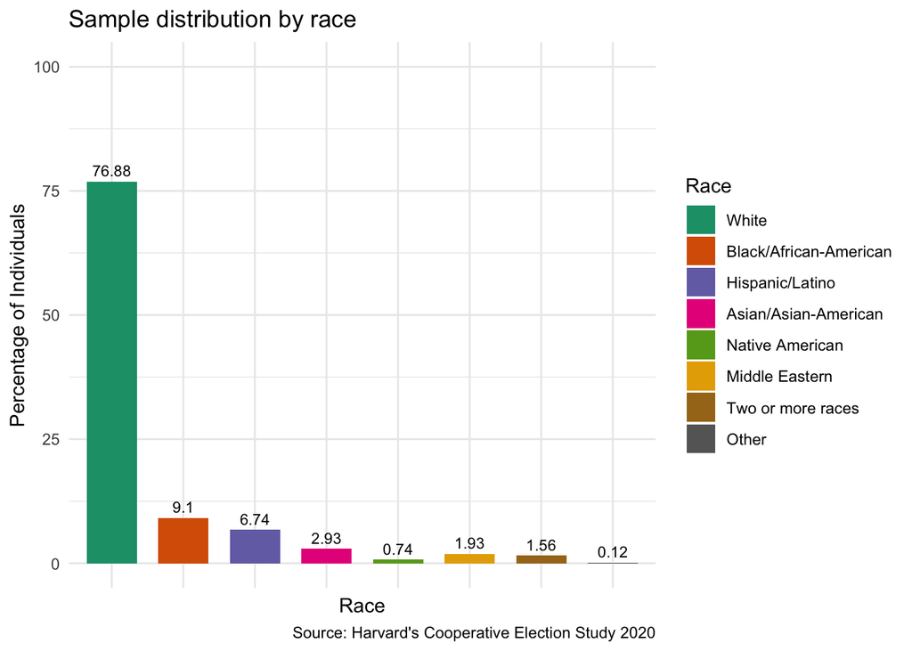

```r
#Sample distribution by race
#Unique value for race variable
voting_data_race <- voting_data %>%
  group_by(race = as.factor(race)) %>%
  count() %>%
  mutate(racepercent = n *100 /dim(voting_data)[1])

#Plotting sample distribution by race
Plot_race <- voting_data %>%
  group_by(race = as.factor(race)) %>%
  summarise(count = n())%>%
  mutate(frequency = (count/sum(count))*100)%>%
  ggplot(aes (x = race, y = frequency, fill = race)) +
  geom_col(stat = "identity", width = 0.7, position = "dodge") +
  geom_text(aes(label = round(frequency, digits = 2)), position = position_dodge(0.7),
            vjust = -0.5, size = 3) +
  theme_minimal() +
  scale_y_continuous(limits = c(0,100)) +
  labs(title = "Sample distribution by race",
    caption ="Source: Harvard's Cooperative Election Study 2020",
    x = "Race",
    y = "Percentage of Individuals",
    fill ="Race") +
  scale_x_discrete(labels = c())+
  scale_fill_brewer(palette="Dark2", labels = c("White", "Black/African-American", "Hispanic/Latino", "Asian/Asian-American", "Native American","Middle Eastern", "Two or more races", "Other", "Unknown"))
print(Plot_race)
```

More than 75% respondents in the Cooperative Election Study are White. Black/African- American and Hispanic/Latino respondents constitute only 16% of the total sample.

###Sample distribution by age

```r
#Sample distribution by age
#Unique value for birthyr variable
voting_data %>%
  group_by(birthyr) %>%
  count()
```

```
## # A tibble: 78 × 2
## # Groups:   birthyr [78]
##    birthyr     n
##      <dbl> <int>
##  1      18    14
##  2      19    17
##  3      20    43
##  4      21    39
##  5      22    53
##  6      23    60
##  7      24    76
##  8      25    83
##  9      26    77
## 10      27    90
## # … with 68 more rows
```

```r
#Making new variables for age-groups
voting_data <- voting_data %>%
  mutate(agegroup = case_when(birthyr >= 18  & birthyr <= 24 ~ '18_24',
                                             birthyr >= 25  & birthyr <= 34 ~ '25_34',
                                             birthyr >= 35  & birthyr <= 44 ~ '35_44',
                                             birthyr >= 45  & birthyr <= 54 ~ '45_55',
                                             birthyr >= 55  & birthyr <=64 ~ '55_64',
                                             birthyr >= 64  & birthyr <= 74 ~ '64_74',
                                             birthyr >= 75  ~ '75+'))
voting_data %>%
  group_by(agegroup) %>%
  count()
```

```
## # A tibble: 7 × 2
## # Groups:   agegroup [7]
##   agegroup     n
##   <chr>    <int>
## 1 18_24      302
## 2 25_34     1137
## 3 35_44     1738
## 4 45_55     1833
## 5 55_64     3232
## 6 64_74     2893
## 7 75+       1553
```

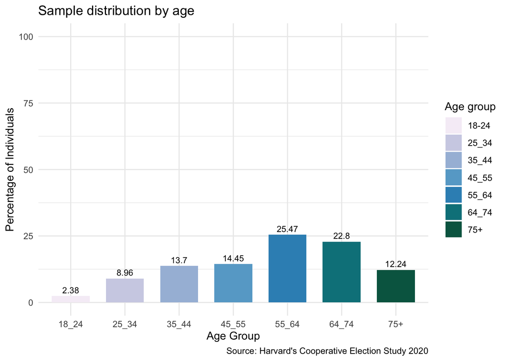

```r
#Plotting age groups
Plot_age <- voting_data %>%
  group_by(agegroup = as.factor(agegroup)) %>%
  summarise(count = n())%>%
  mutate(frequency = (count/sum(count))*100)%>%
  ggplot(aes (x = agegroup, y = frequency, fill = agegroup)) +
  geom_col(stat = "identity", width = 0.7, position = "dodge") +
  geom_text(aes(label = round(frequency, digits = 2)), position = position_dodge(0.7),
            vjust = -0.5, size = 3) +
  theme_minimal() +
  scale_y_continuous(limits = c(0,100)) +
  labs(title = "Sample distribution by age",
    caption ="Source: Harvard's Cooperative Election Study 2020",
    x = "Age Group",
    y = "Percentage of Individuals",
    fill ="Age group") +
  scale_x_discrete(labels = c("18_24", "25_34","35_44", "45_55", "55_64", "64_74", "75+")) +
  scale_fill_brewer(palette="PuBuGn", labels = c("18-24", "25_34","35_44", "45_55", "55_64", "64_74", "75+"))
print(Plot_age)
```

###Sample distribution by sexuality

```r
##Sample distribution by sexuality
#Unique values for sexuality
voting_data %>%
  group_by(sexuality) %>%
  count()
```

```
## # A tibble: 6 × 2
## # Groups:   sexuality [6]
##   sexuality     n
##       <dbl> <int>
## 1         1 11204
## 2         2   171
## 3         3   556
## 4         4   403
## 5         5    98
## 6         6   256
```

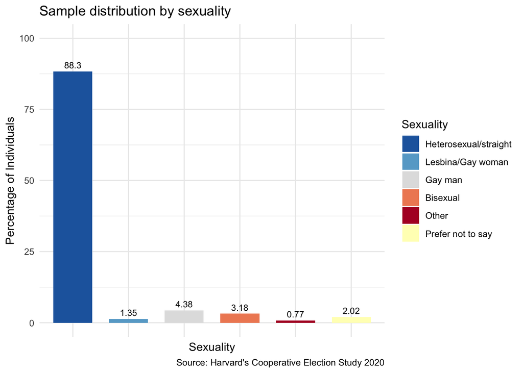

```r
#Plotting sexuality distribution in sample
Plot_sex <- voting_data %>%
  group_by(sexuality = as.factor(sexuality)) %>%
  na.omit() %>%
  summarise(count = n())%>%
  mutate(frequency = (count/sum(count))*100)%>%
  ggplot(aes (x = sexuality, y = frequency, fill =sexuality)) +
  geom_col(stat = "identity", width = 0.7, position = "dodge") +
  geom_text(aes(label = round(frequency, digits = 2)), position = position_dodge(0.7),
            vjust = -0.5, size = 3) +
  theme_minimal() +
  scale_y_continuous(limits = c(0,100)) +
  labs(title = "Sample distribution by sexuality",
    caption ="Source: Harvard's Cooperative Election Study 2020",
    x = "Sexuality",
    y = "Percentage of Individuals",
    fill = "Sexuality") +
  scale_x_discrete(labels = c())+
  scale_fill_manual(values = c("#2166ac", "#67a9cf","#e0e0e0", "#ef8a62","#b2182b", "#ffffbf"), labels = c("Heterosexual/straight", "Lesbina/Gay woman","Gay man", "Bisexual", "Other", "Prefer not to say"))
print(Plot_sex)
```

Almost 88% of the respondents identify as Heterosexual/straight. The LGBTQI community constitutes less than 10% of the sample.

###Sample distribution by gender

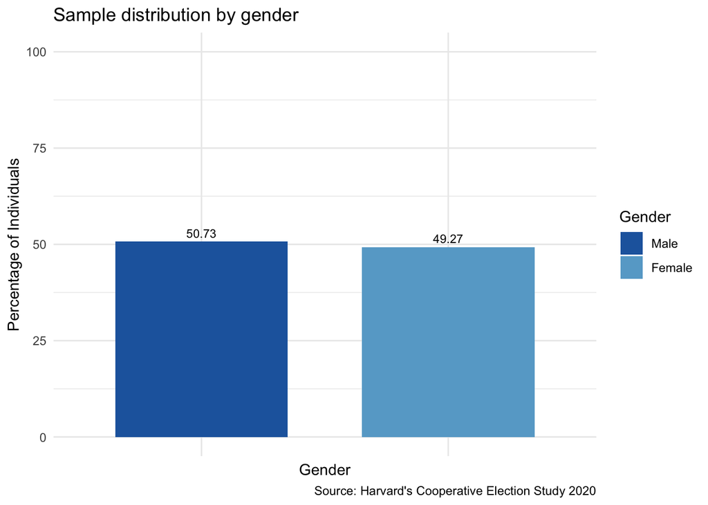

```r
##Sample distribution by gender
Plot_gen <- voting_data %>%
  group_by(gender = as.factor(gender)) %>%
  summarise(count = n())%>%
  mutate(frequency = (count/sum(count))*100) %>%
  ggplot(aes (x = gender, y = frequency, fill=gender)) +
  geom_col(stat = "identity", width = 0.7, position = "dodge") +
  geom_text(aes(label = round(frequency, digits = 2)), position = position_dodge(0.7),
            vjust = -0.5, size = 3)+
  theme_minimal() +
  scale_y_continuous(limits = c(0,100)) +
  labs(title = "Sample distribution by gender",
    caption ="Source: Harvard's Cooperative Election Study 2020",
    x = "Gender",
    y = "Percentage of Individuals",
    fill = "Gender") +
  scale_x_discrete(labels = c())+
  scale_fill_manual(values = c("#2166ac", "#67a9cf"), labels = c("Male", "Female"))
print(Plot_gen)
```

The sample distribution is inclusive when it comes to gender. It has an almost equal proportion of men and women.

#Sample distribution by education

```r
##Sample distribution by education
#Unique values for education
voting_data %>%
  group_by(educ) %>%
  count()
```

```
## # A tibble: 6 × 2
## # Groups:   educ [6]
##    educ     n
##   <dbl> <int>
## 1     1   114
## 2     2  2220
## 3     3  2404
## 4     4  1342
## 5     5  3787
## 6     6  2821
```

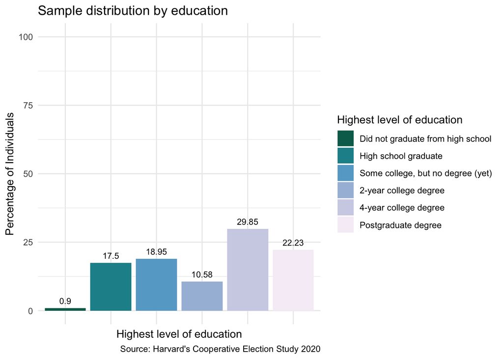

```r
#Plotting the distribution
plot_edu <- voting_data %>%
  select(educ) %>%
  na.omit() %>%
  group_by(educ = as.factor(educ)) %>%
  summarise(count =  n()) %>%
  mutate(frequency = (count/sum(count))*100) %>%
  ggplot(aes(x = educ, y = frequency , fill = educ)) +
  geom_col(stat = "identity", width = 0.9, position = "dodge") +
  geom_text(aes(label = round(frequency, digits = 2)), position = position_dodge(0.9),
            vjust = -0.7, size = 3) +
  scale_y_continuous(limits = c(0,100))+
  labs (title = "Sample distribution by education",
        x = "Highest level of education",
        y = "Percentage of Individuals",
        fill = "Highest level of education",
        caption = "Source: Harvard's Cooperative Election Study 2020") +
  theme_minimal() +
  scale_x_discrete(labels = c())+
  scale_fill_brewer(palette="PuBuGn", labels = c("Did not graduate from high school", "High school graduate", "Some college, but no degree (yet)", "2-year college degree", "4-year college degree", "Postgraduate degree"), direction = -1)
print(plot_edu)
```

###Sample distribution by voting behaviour

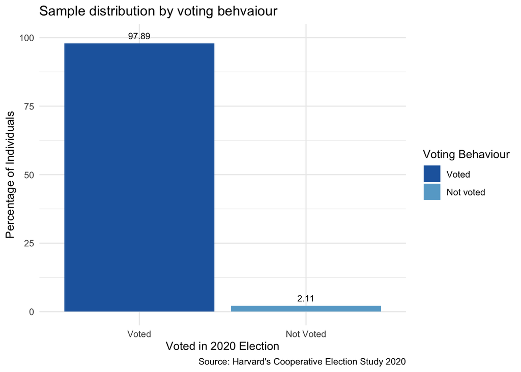

```r
##Sample distribution by voting behaviour
Plot_vot <- voting_data %>%
  group_by(voted = as.factor(voted)) %>%
  na.omit() %>%
  summarise(count =  n()) %>%
  mutate(frequency = (count/sum(count))*100) %>%
  ggplot(aes(x = voted, y = frequency , fill = voted)) +
  geom_col(stat = "identity", width = 0.9, position = "dodge") +
  geom_text(aes(label = round(frequency, digits = 2)), position = position_dodge(0.9),
            vjust = -0.7, size = 3) +
  scale_x_discrete(labels = c("Voted", "Not Voted")) +
  scale_y_continuous(limits = c(0,100))+
  labs (title = "Sample distribution by voting behvaiour",
        x = "Voted in 2020 Election",
        y = "Percentage of Individuals",
        caption = "Source: Harvard's Cooperative Election Study 2020",
        fill = "Voting Behaviour") +
  theme_minimal()+
  scale_fill_manual(values = c("#2166ac", "#67a9cf"), labels = c("Voted", "Not voted"))
print(Plot_vot)
```

Close to 98% of all respondents said that they voted in the 2020 elections.

###Exploratory Data Analysis ### Race distribution by voting behaviour

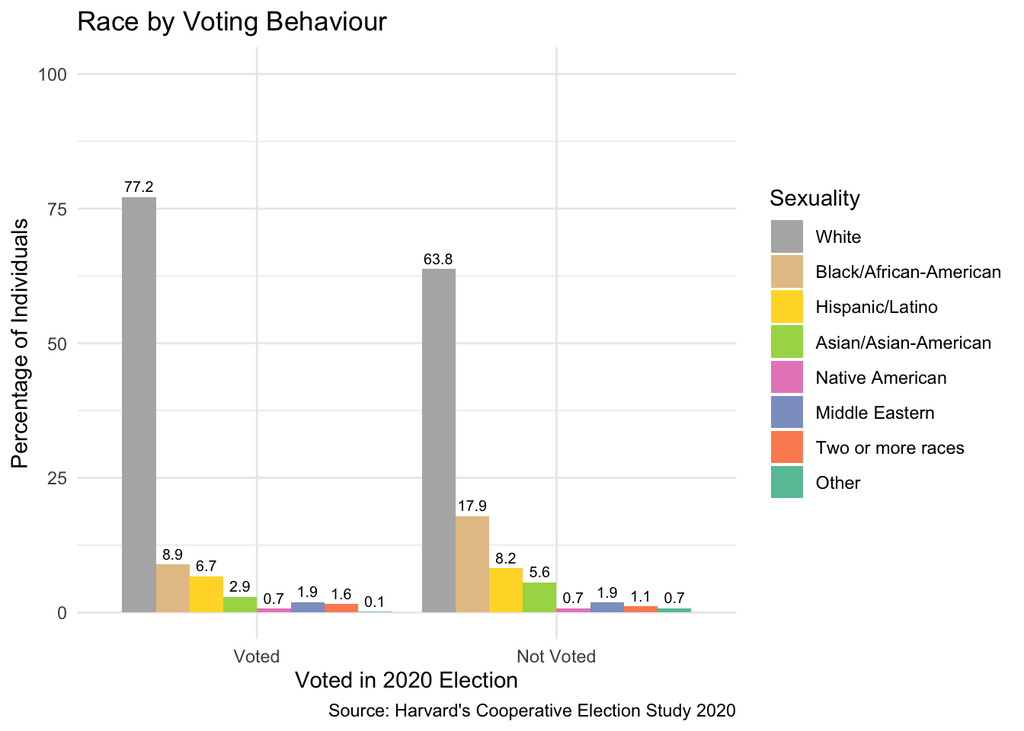

```r
#Plotting race distribution by voting behaviour
Plot_vrace <- voting_data %>%
  select(voted, race) %>%
  na.omit() %>%
  group_by(voted = as.factor(voted), race = as.factor(race)) %>%
  summarise(count =  n()) %>%
  mutate(frequency = (count/sum(count))*100) %>%
  ggplot(aes(x = voted, y = frequency , fill = race)) +
  geom_col(stat = "identity", width = 0.9, position = "dodge") +
  geom_text(aes(label = round(frequency, digits = 1)), position = position_dodge(0.9),
            vjust = -0.5, size = 2.6) +
  scale_x_discrete(labels = c("Voted", "Not Voted")) +
  scale_y_continuous(limits = c(0,100))+
  labs (title = "Race by Voting Behaviour",
        x = "Voted in 2020 Election",
        y = "Percentage of Individuals",
        fill = "Sexuality",
        caption = "Source: Harvard's Cooperative Election Study 2020") +
  theme_minimal() +
  scale_fill_brewer(palette="Set2", labels = c("White", "Black/African-American", "Hispanic/Latino", "Asian/Asian-American", "Native American","Middle Eastern", "Two or more races", "Other", "Unknown"), direction = -1)
print(Plot_vrace)
```

77.2% of the individuals who voted are White while only 63.8% of the individuals who did not vote are White. Among those who voted, almost 9% were Black/African-American. Blacks constitute a higher percentage of those who did not vote at 17.9%. Minority communities constitute a higher proportion of the group that did not vote as compared to those who did.

#Age distribution by voting behaviour

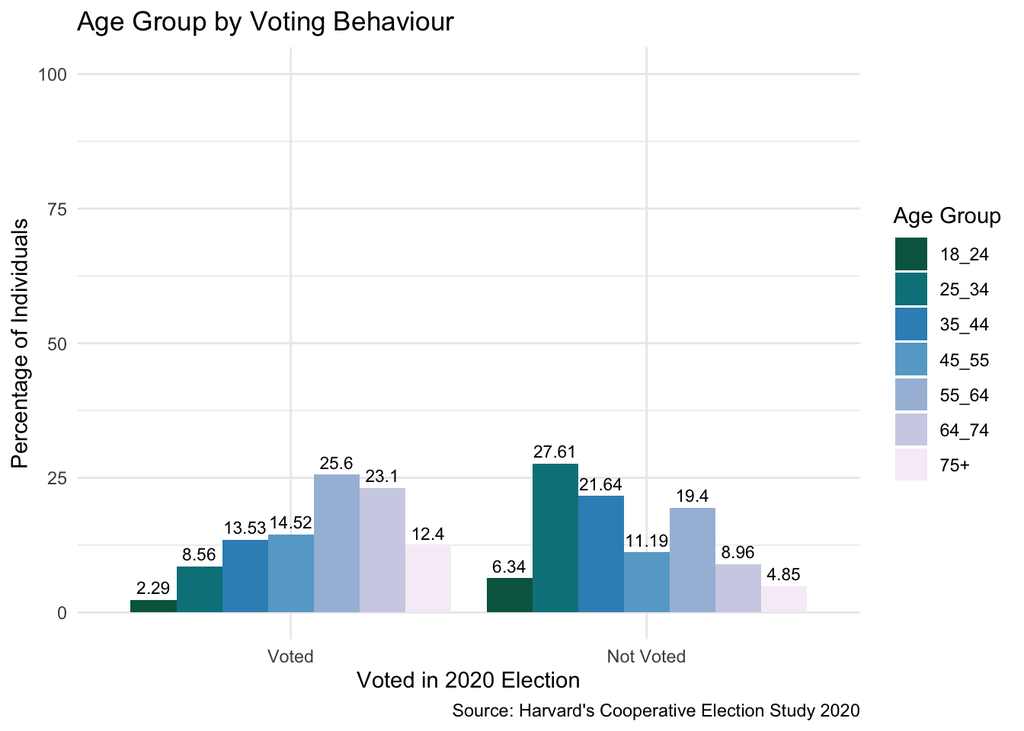

```r
#Plotting age distribution by voting behaviour
Plot_vage <- voting_data %>%
  select(voted, agegroup) %>%
  na.omit() %>%
  group_by(voted = as.factor(voted), agegroup = as.factor(agegroup)) %>%
  summarise(count =  n()) %>%
  mutate(frequency = (count/sum(count))*100) %>%
  ggplot(aes(x = voted, y = frequency , fill = agegroup)) +
  geom_col(stat = "identity", width = 0.9, position = "dodge") +
  geom_text(aes(label = round(frequency, digits = 2)), position = position_dodge(0.9),
            vjust = -0.5, size = 3) +
  scale_x_discrete(labels = c("Voted", "Not Voted")) +
  scale_y_continuous(limits = c(0,100))+
  labs (title = "Age Group by Voting Behaviour",
        x = "Voted in 2020 Election",
        y = "Percentage of Individuals",
        fill = "Age Group",
        caption = "Source: Harvard's Cooperative Election Study 2020") +
  theme_minimal() +
  scale_fill_brewer(palette="PuBuGn", labels = c("18_24", "25_34","35_44", "45_55", "55_64", "64_74", "75+"), direction = -1)
print(Plot_vage)
```

#Sexuality by voting behaviour

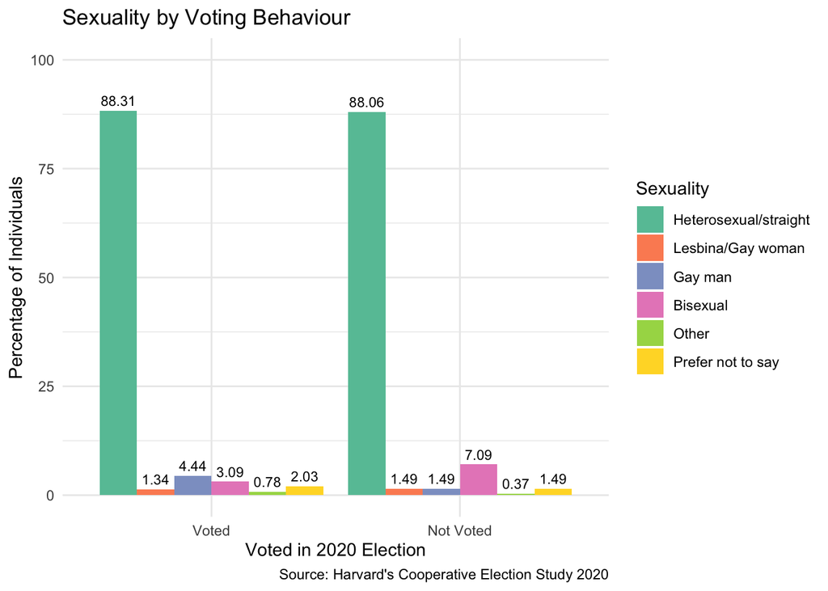

```r
#Plotting sexuality by voting behaviour
Plot_vsex <- voting_data %>%
  select(voted, sexuality) %>%
  na.omit() %>%
  group_by(voted = as.factor(voted), sexuality = as.factor(sexuality)) %>%
  summarise(count =  n()) %>%
  mutate(frequency = (count/sum(count))*100) %>%
  ggplot(aes(x = voted, y = frequency , fill = sexuality)) +
  geom_col(stat = "identity", width = 0.9, position = "dodge") +
  geom_text(aes(label = round(frequency, digits = 2)), position = position_dodge(0.9),
            vjust = -0.5, size = 3) +
  scale_x_discrete(labels = c("Voted", "Not Voted")) +
  scale_y_continuous(limits = c(0,100))+
  labs (title = "Sexuality by Voting Behaviour",
        x = "Voted in 2020 Election",
        y = "Percentage of Individuals",
        fill = "Sexuality",
        caption = "Source: Harvard's Cooperative Election Study 2020") +
  theme_minimal() +
  scale_fill_brewer(palette="Set2", labels = c("Heterosexual/straight", "Lesbina/Gay woman","Gay man", "Bisexual", "Other", "Prefer not to say"))
print(Plot_vsex)
```

Since the sample is dominated by individuals who identify as heterosexual/straight, the percentage of those who did not vote and well as those who did is majorly this group. Since LGBTQI community is not well-represented in this data set, it is hard to draw any conclusions about the correlation between sexuality and voting behaviour.

#Employment by voting behaviour

```r
#Unique values for employment
voting_data %>%
  group_by(employ) %>%
  count()
```

```
## # A tibble: 9 × 2
## # Groups:   employ [9]
##   employ     n
##    <dbl> <int>
## 1      1  4725
## 2      2  1156
## 3      3   245
## 4      4   694
## 5      5  4263
## 6      6   611
## 7      7   553
## 8      8   192
## 9      9   249
```

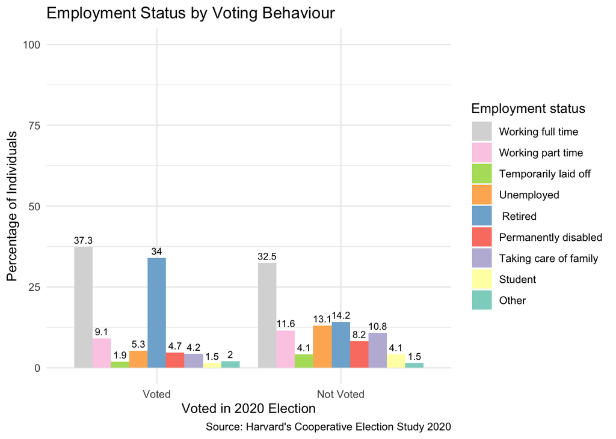

```r
#Plotting employment by voting behaviour
Plot_vemp <- voting_data %>%
  select(voted, employ) %>%
  na.omit() %>%
  group_by(voted = as.factor(voted), employ = as.factor(employ)) %>%
  summarise(count =  n()) %>%
  mutate(frequency = (count/sum(count))*100) %>%
  ggplot(aes(x = voted, y = frequency , fill = employ)) +
  geom_col(stat = "identity", width = 0.9, position = "dodge") +
  geom_text(aes(label = round(frequency, digits =1)), position = position_dodge(0.9),
            vjust = -0.5, size = 2.8) +
  scale_x_discrete(labels = c("Voted", "Not Voted")) +
  scale_y_continuous(limits = c(0,100))+
  labs (title = "Employment Status by Voting Behaviour",
        x = "Voted in 2020 Election",
        y = "Percentage of Individuals",
        fill = "Employment status",
        caption = "Source: Harvard's Cooperative Election Study 2020") +
  theme_minimal() +
  scale_fill_brewer(palette="Set3", labels = c("Working full time", "Working part time","Temporarily laid off", "Unemployed", " Retired", "Permanently disabled", "Taking care of family", "Student", "Other"), direction = -1)
print(Plot_vemp)
```